# Predicting price of `diamonds`

Business Analytics (23/24)

In this document, we will perform a numeric prediction job using the `diamonds` dataset from `ggplot2`. As `ggplot2` is included in tidymodels, we will need only the `tidymodels` package.

```r
library(tidymodels)
```

# 1 The `diamonds` Dataset

The dataset contains the prices and other attributes of almost 54,000 diamonds.

```r
data("diamonds")
diamonds
```

```
# A tibble: 53,940 × 10
   carat cut       color clarity depth table price     x     y     z
   <dbl> <ord>     <ord> <ord>   <dbl> <dbl> <int> <dbl> <dbl> <dbl>
 1  0.23 Ideal     E     SI2      61.5    55   326  3.95  3.98  2.43
 2  0.21 Premium   E     SI1      59.8    61   326  3.89  3.84  2.31
 3  0.23 Good      E     VS1      56.9    65   327  4.05  4.07  2.31
 4  0.29 Premium   I     VS2      62.4    58   334  4.2   4.23  2.63
 5  0.31 Good      J     SI2      63.3    58   335  4.34  4.35  2.75
 6  0.24 Very Good J     VVS2     62.8    57   336  3.94  3.96  2.48
 7  0.24 Very Good I     VVS1     62.3    57   336  3.95  3.98  2.47
 8  0.26 Very Good H     SI1      61.9    55   337  4.07  4.11  2.53
 9  0.22 Fair      E     VS2      65.1    61   337  3.87  3.78  2.49
10  0.23 Very Good H     VS1      59.4    61   338  4     4.05  2.39
# ℹ 53,930 more rows
```

## 1.1 The target variable

Our job will be predicting the `price` variable, thus it is a regression or numerical prediction job. It is always a good idea to examine the target variable.

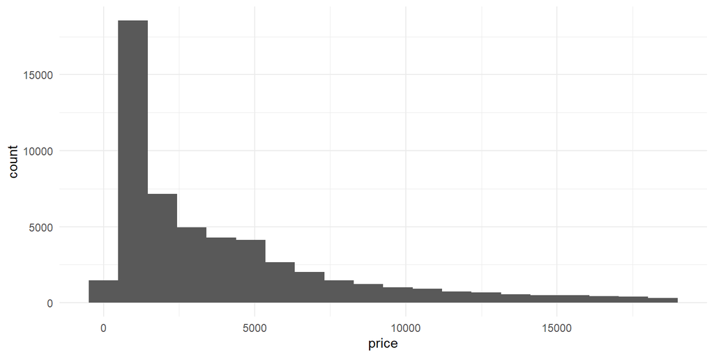

```r
diamonds |>
  ggplot(aes(price)) +
  geom_histogram(bins = 20) +
  theme_minimal()
```

We can see that the variable is highly **right-skewed**, meaning that there are many samples with a price higher than the expected if the variable followed a normal law.

In those cases, it is a good idea to use the **logarithm** of the variable as a predictor. The transformations of the target variable must be done outside the prediction workflow, so we define `log_price` as:

```r
diamonds <- diamonds |>
  mutate(log_price = log(price))
```

The distribution of `log_price` is:

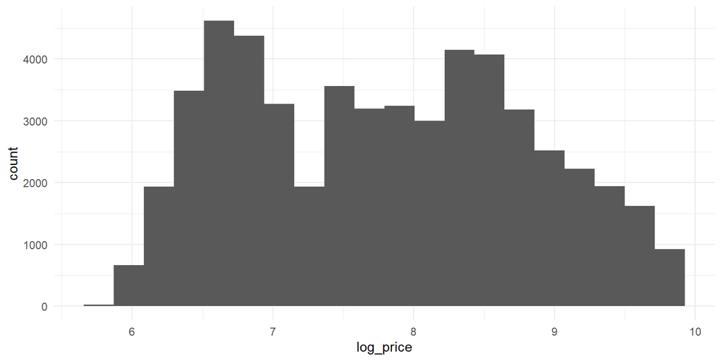

```r
diamonds |>
  ggplot(aes(log_price)) +
  geom_histogram(bins = 20) +
  theme_minimal()
```

We observe that `log_price` has a more adequate distribution for predictive modelling.

## 1.2 The Features

The features of the dataset are some diamond properties. Features from cut to clarity are set as **ordered factors**, meaning that factor levels are ordinal variables. This means that we can turn them into ordinal variables, rather than a set of dummies.

The other features are numeric, and have to do with diamond size. `carat` is a measure of diamond weight, and `x`,`y`, `z`, `depth` and `table` are measures of diamond size.

As larger diamonds will also be larger, it is not surprising to find high values of correlation between those variables. Let’s use the `corrr` package to see them.

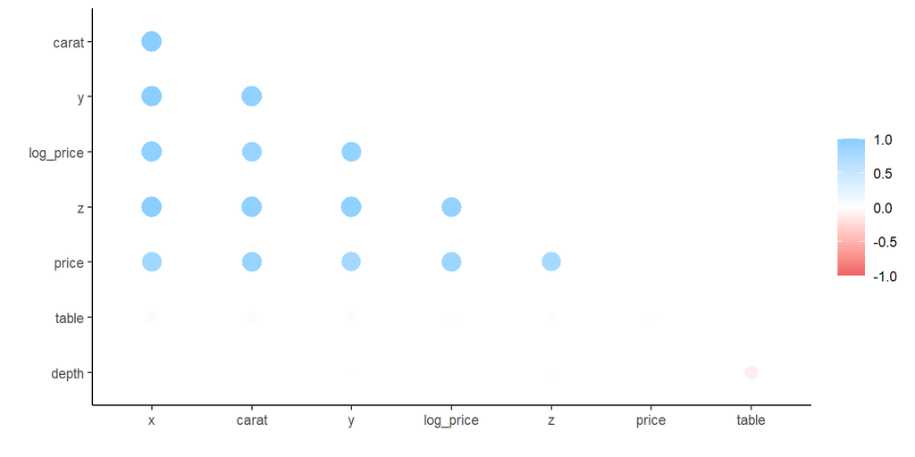

```r
library(corrr)
diamonds |>
  select(where(is.numeric)) |>
  correlate() |>
  rearrange() |>
  shave() |>
  rplot()
```

Let’s see how the geometrical `x` variable relates with `log_price`.

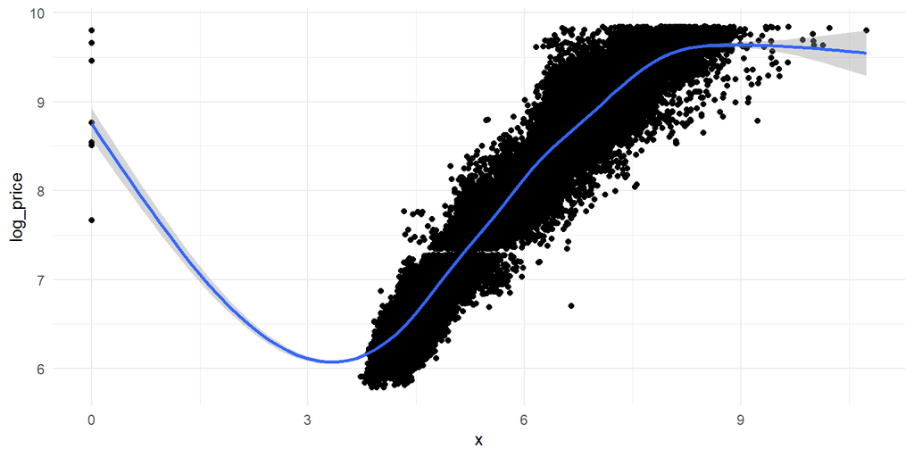

```r
diamonds |>
  ggplot(aes(x, log_price)) +
  geom_point() +
  geom_smooth() +
  theme_minimal()
```

There are some diamonds of geometry zero.

```r
diamonds |>
  filter(x == 0 | y == 0 | z == 0)
```

```
# A tibble: 20 × 11
   carat cut       color clarity depth table price     x     y     z log_price
   <dbl> <ord>     <ord> <ord>   <dbl> <dbl> <int> <dbl> <dbl> <dbl>     <dbl>
 1  1    Premium   G     SI2      59.1    59  3142  6.55  6.48     0      8.05
 2  1.01 Premium   H     I1       58.1    59  3167  6.66  6.6      0      8.06
 3  1.1  Premium   G     SI2      63      59  3696  6.5   6.47     0      8.22
 4  1.01 Premium   F     SI2      59.2    58  3837  6.5   6.47     0      8.25
 5  1.5  Good      G     I1       64      61  4731  7.15  7.04     0      8.46
 6  1.07 Ideal     F     SI2      61.6    56  4954  0     6.62     0      8.51
 7  1    Very Good H     VS2      63.3    53  5139  0     0        0      8.54
 8  1.15 Ideal     G     VS2      59.2    56  5564  6.88  6.83     0      8.62
 9  1.14 Fair      G     VS1      57.5    67  6381  0     0        0      8.76
10  2.18 Premium   H     SI2      59.4    61 12631  8.49  8.45     0      9.44
11  1.56 Ideal     G     VS2      62.2    54 12800  0     0        0      9.46
12  2.25 Premium   I     SI1      61.3    58 15397  8.52  8.42     0      9.64
13  1.2  Premium   D     VVS1     62.1    59 15686  0     0        0      9.66
14  2.2  Premium   H     SI1      61.2    59 17265  8.42  8.37     0      9.76
15  2.25 Premium   H     SI2      62.8    59 18034  0     0        0      9.80
16  2.02 Premium   H     VS2      62.7    53 18207  8.02  7.95     0      9.81
17  2.8  Good      G     SI2      63.8    58 18788  8.9   8.85     0      9.84
18  0.71 Good      F     SI2      64.1    60  2130  0     0        0      7.66
19  0.71 Good      F     SI2      64.1    60  2130  0     0        0      7.66
20  1.12 Premium   G     I1       60.4    59  2383  6.71  6.67     0      7.78
```

Let’s see how `carat` works:

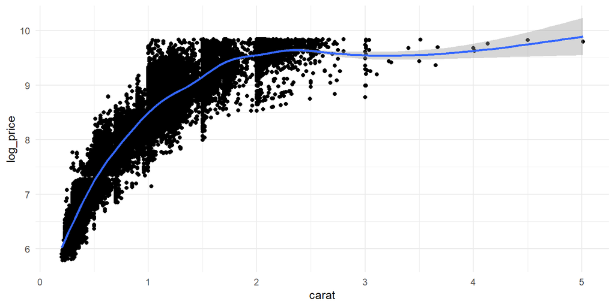

```r
diamonds |>
  ggplot(aes(carat, log_price)) +
  geom_point() +
  geom_smooth() +
  theme_minimal()
```

We observe a strong, nonlinear relationship between `carat` and `price`. `carat` can be a better feature than `x:z` variables, as it has no anomalous zero values, so we will skip them and keep `carat` as feature.

# 2 Predicting Diamond Prices

Let’s define the elements of a workflow to predict diamond prices.

## 2.1 Initial Split

Performing an adequate split of the dataset into train and test sets. Keeping 90% of data for the training set.

```r
set.seed(44)
d_split <- initial_split(diamonds, prop = 0.9)
```

## 2.2 Preprocessing

Some useful steps for preprocessing:

Performing preprocessing steps in a recipe.

```r
d_rec <- recipe(log_price ~ ., training(d_split)) |>
  update_role(price, new_role = "original predictor") |>
  step_ordinalscore(all_nominal_predictors()) |>
   step_rm(x:z) |>
  step_sqrt(carat) |>
  step_nzv(all_predictors())
```

*We can see the preprocessed dataset doing:*

```r
d_rec |>
  prep() |>
  bake(new_data = NULL)
```

```
# A tibble: 48,546 × 8
   carat   cut color clarity depth table price log_price
   <dbl> <int> <int>   <int> <dbl> <dbl> <int>     <dbl>
 1 1.24      4     7       4  62.9    59  7554      8.93
 2 0.616     5     2       5  62.1    56  1000      6.91
 3 1.01      4     3       2  61.4    57  4586      8.43
 4 0.548     2     2       5  63.2    57   568      6.34
 5 0.566     3     3       6  63.8    55   701      6.55
 6 0.469     1     2       4  65.1    61   337      5.82
 7 0.566     4     1       3  60.9    60   589      6.38
 8 1.00      5     4       3  62.9    56  5107      8.54
 9 0.548     3     1       4  62.5    57   670      6.51
10 1.01      5     4       8  62.5    57  8162      9.01
# ℹ 48,536 more rows
```

*And we can see the roles of variables:*

```r
d_rec |>
  prep() |>
  summary()
```

```
# A tibble: 8 × 4
  variable  type      role               source
  <chr>     <list>    <chr>              <chr>
1 carat     <chr [2]> predictor          original
2 cut       <chr [2]> predictor          original
3 color     <chr [2]> predictor          original
4 clarity   <chr [2]> predictor          original
5 depth     <chr [2]> predictor          original
6 table     <chr [2]> predictor          original
7 price     <chr [2]> original predictor original
8 log_price <chr [2]> outcome            original
```

## 2.3 Models

Define=ing two predictive models:

- A **ensemble-based** model, like boosted trees.
- A **regression-based** model, like regularized regression.

```r
rr <- linear_reg(mode = "regression", engine = "glmnet", penalty = 0, mixture = 1)

bt <- boost_tree(mode = "regression") |>
  set_engine("xgboost")
```

*And the workflows:*

```r
d_rr_wf <- workflow() |>
  add_recipe(d_rec) |>
  add_model(rr)

d_bt_wf <- workflow() |>
  add_recipe(d_rec) |>
  add_model(bt)
```

*Let’s store both workflows into a list.*

```r
d_wf <- list(d_rr_wf, d_bt_wf)
names(d_wf) <- c("reg_regression", "boosted_trees")
```

## 2.4 Cross Validation

Defining a set of ten folders for the training set, and testing the two models with cross validation using as metrics mean absolute error `mae`, root of mean squared errors `rmse` and r squared `rsq`.

*The folds:*

```r
set.seed(11)
folds <- vfold_cv(training(d_split), v = 10)
```

*The metrics:*

```r
reg_metrics <- metric_set(mae, rmse, rsq)
```

*Let’s test the two models at the same time with `lapply()`.*

```r
d_cv <- lapply(d_wf, \(m) m |> fit_resamples(folds, metrics = reg_metrics) |> collect_metrics())
```

## 2.5 Model Decision

*Let’s see the results:*

```r
d_cv
```

```
$reg_regression
# A tibble: 3 × 6
  .metric .estimator  mean     n  std_err .config
  <chr>   <chr>      <dbl> <int>    <dbl> <chr>
1 mae     standard   0.166    10 0.000860 Preprocessor1_Model1
2 rmse    standard   0.215    10 0.00157  Preprocessor1_Model1
3 rsq     standard   0.955    10 0.000533 Preprocessor1_Model1

$boosted_trees
# A tibble: 3 × 6
  .metric .estimator   mean     n  std_err .config
  <chr>   <chr>       <dbl> <int>    <dbl> <chr>
1 mae     standard   0.0858    10 0.000314 Preprocessor1_Model1
2 rmse    standard   0.110     10 0.000568 Preprocessor1_Model1
3 rsq     standard   0.990     10 0.000114 Preprocessor1_Model1
```

*We observe that the boosted trees model is the one that performs best.*

# 3 Final Model

## 3.1 Training the Model

Training a model for diamond pricing on the whole training set.

```r
model <- d_bt_wf |>
  fit(training(d_split))
```

## 3.2 Performance of `log_price`

Evaluating the performance of the model in the test set.

```r
model |>
  predict(testing(d_split)) |>
  bind_cols(testing(d_split)) |>
  reg_metrics(truth = log_price, estimate = .pred)
```

```
# A tibble: 3 × 3
  .metric .estimator .estimate
  <chr>   <chr>          <dbl>
1 mae     standard      0.0878
2 rmse    standard      0.113
3 rsq     standard      0.989
```

*We can plot target versus prediction:*

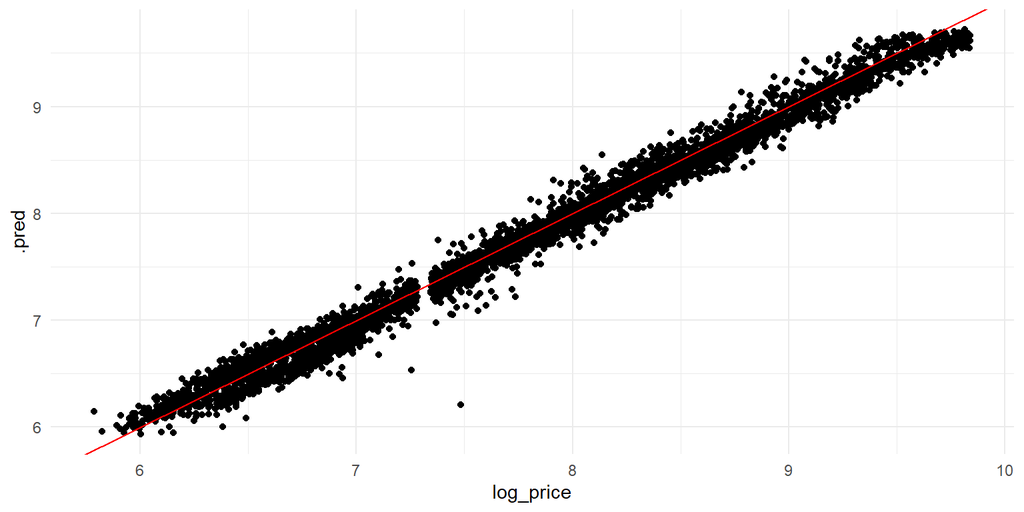

```r
model |>
  predict(testing(d_split)) |>
  bind_cols(testing(d_split)) |>
  ggplot(aes(log_price, .pred)) +
  geom_point() +
  geom_abline(slope = 1, intercept = 0, color = "red") +
  theme_minimal()
```

## 3.3 Performance with `price`

Evaluating the performance of the model on the test set using the original price variable and the exponential transformation of the prediction.

*We need to obtain the real price using the reverse function of `log()` that is `exp()`.*

```r
model |>
  predict(testing(d_split)) |>
  bind_cols(testing(d_split)) |>
  mutate(price_pred = exp(.pred)) |>
  reg_metrics(truth = price, estimate = price_pred)
```

```
# A tibble: 3 × 3
  .metric .estimator .estimate
  <chr>   <chr>          <dbl>
1 mae     standard     340.
2 rmse    standard     632.
3 rsq     standard       0.979
```

*The target versus prediction plot shows high variability in prediction for high prices.*

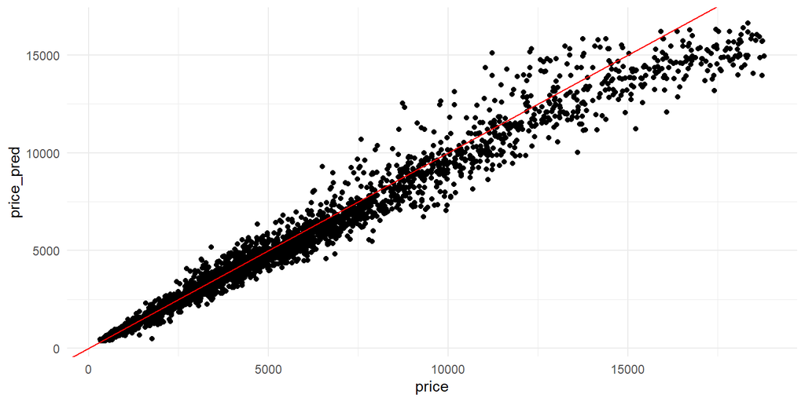

```r
model |>
  predict(testing(d_split)) |>
  bind_cols(testing(d_split)) |>
  mutate(price_pred = exp(.pred)) |>
  ggplot(aes(price, price_pred)) +
  geom_point() +
  geom_abline(slope = 1, intercept = 0, color = "red") +
  theme_minimal()
```